# Item Analysis, EFA, and CFA

# Item Analysis

Item analysis is usually done on a construct level. In this data set, we have six different constructs and items which theoretically belong to only one of these constructs. Thus, it makes sense to investigate item characteristics on a construct level and not on a full-scale level. However, this is context specific, and there might be situations where a scale-level analysis is more appropriate.

According to Moosbrugger & Kelava (2008), it is advisable to investigate 1) the difficulty, 2) variance and 3) discriminatory power of items.

First, we will name the items correctly.

```r
df <- data[,c(9:103)]
df$v_563 <- NULL # remove attention check 1
df$v_455 <- NULL # remove attention check 2
df <- as.data.frame(df)
var_names <- read.table(url("https://bruehlmann.io/projects/umi/data/var_names.txt"))
constructs <- read.table(url("https://bruehlmann.io/projects/umi/data/const_names.txt"))
names(df) <- var_names$x
constructs <- constructs$x
df <- df[ , order(names(df))] # reorder based on varname
```

## Item descriptives

### Overall

To get a general impression of how the items perform, we can look at the lowest and highest values found in the data.

```r
apply(describe(df)[,3:13], 2, min) # return the minimum values found in the data
```

```
       mean          sd      median     trimmed         mad         min         max       range        skew
 1.30720339  0.88141116  1.00000000  1.06349206  0.00000000  1.00000000  7.00000000  6.00000000 -0.98718296
   kurtosis          se
-1.27175864  0.04057024
```

```r
apply(describe(df)[,3:13], 2, max) # maximum values found
```

```
       mean          sd      median     trimmed         mad         min         max       range        skew
 5.51271186  1.97295284  6.00000000  5.65608466  2.96520000  1.00000000  7.00000000  6.00000000  3.85705462
   kurtosis          se
15.83220197  0.09081252
```

We usually do not report this in a paper. Item descriptives should be reported for each item individually. For 93 items, this should be put in the appendix or the supplementary materials. For smaller scales, descriptives can be included in the paper.

### Separate for each construct

```r
for(i in constructs) {
  print(apply(describe(df[,grep(i, names(df))]), 2, mean))
}
```

```
        vars            n         mean           sd       median      trimmed          mad          min          max
  8.50000000 472.00000000   2.43789725   1.69393243   1.93750000   2.18716931   1.38993750   1.00000000   7.00000000
       range         skew     kurtosis           se
  6.00000000   0.97350232  -0.14266095   0.07796956
       vars           n        mean          sd      median     trimmed         mad         min         max
  6.5000000 472.0000000   1.9650424   1.3929757   1.2500000   1.6973104   0.3706500   1.0000000   7.0000000
      range        skew    kurtosis          se
  6.0000000   1.7512917   3.3199436   0.0641169
        vars            n         mean           sd       median      trimmed          mad          min          max
  9.50000000 472.00000000   2.29037194   1.52991157   1.77777778   2.03953557   0.82366667   1.00000000   7.00000000
       range         skew     kurtosis           se
  6.00000000   1.34255072   1.64142999   0.07041989
        vars            n         mean           sd       median      trimmed          mad          min          max
  6.50000000 472.00000000   4.04519774   1.71104548   4.08333333   4.05158730   1.60615000   1.00000000   7.00000000
       range         skew     kurtosis           se
  6.00000000  -0.15723867  -0.61775669   0.07875725
        vars            n         mean           sd       median      trimmed          mad          min          max
 10.50000000 472.00000000   2.94184322   1.80687335   2.70000000   2.76150794   2.29803000   1.00000000   7.00000000
       range         skew     kurtosis           se
  6.00000000   0.53830477  -0.76337256   0.08316809
        vars            n         mean           sd       median      trimmed          mad          min          max
  8.00000000 472.00000000   5.01920904   1.50687259   5.20000000   5.14444444   1.53202000   1.00000000   7.00000000
       range         skew     kurtosis           se
  6.00000000  -0.66369543   0.03582029   0.06935943
```

## Difficulty indices

The difficulty of an item is an important property for performance tests or other psychological tests. It describes the “easiness” of an item, meaning that an item with a higher difficulty was more often answered correctly by the participants. Ideally, an item has a difficulty that is not too low (too hard) but also not too high (too easy), since these items do not differentiate well between participants.

Difficulty in the context of Likert scale items means: The smaller the value, the harder (on average) it is to agree to this item.

**The answers to the items need to be between 0 and k-1.** K describes the number of steps on the scale. Based on Dahl (1971) in Moosbrugger & Kevala (2008), the difficulty index for scales with k > 2 levels can be calculated with this formula:

$$P_{i}=\frac{\sum\limits_{v=1}^n{x_{vi}}}{n\cdot(k-1)}\cdot100$$

The difficulty index of an item is thus the average of item answers for n participants on the k-steps scale. The larger this value, the “easier” it is on average to agree to this item.

An ideal difficulty index is about 50. But it depends on the application of the questionnaire whether a lower or higher difficulty is acceptable. For instance, if we want to have a measure that is also able to distinguish in the extremes of a feature or trait, we should include items with high and low difficulty. However, these items should also have a large discriminatory power.

```r
diff_index <- colSums(df-1, na.rm = TRUE) / (nrow(df-1)*(max(df-1, na.rm = TRUE))) * 100
diff_index
```

```
     1_AMOTIV_120       1_AMOTIV_13       1_AMOTIV_16      1_AMOTIV_189      1_AMOTIV_191      1_AMOTIV_192
        25.812147         19.526836         25.388418         22.881356         24.046610         25.741525
     1_AMOTIV_213      1_AMOTIV_214      1_AMOTIV_215      1_AMOTIV_216      1_AMOTIV_226      1_AMOTIV_228
        25.600282         24.964689         24.470339         25.423729         25.211864         23.163842
      1_AMOTIV_52       1_AMOTIV_83       1_AMOTIV_84       1_AMOTIV_85    2_EXTERNAL_100    2_EXTERNAL_119
        24.682203         25.388418         23.269774         17.867232         18.114407         17.620056
   2_EXTERNAL_162    2_EXTERNAL_164    2_EXTERNAL_165    2_EXTERNAL_237    2_EXTERNAL_239     2_EXTERNAL_30
        24.435028         22.033898         11.617232          5.120056         31.108757          5.896893
    2_EXTERNAL_32     2_EXTERNAL_48     2_EXTERNAL_66     2_EXTERNAL_67 3_INTROJECTED_115 3_INTROJECTED_116
        12.358757         10.381356         18.079096         16.242938         31.638418         13.276836
3_INTROJECTED_137 3_INTROJECTED_159 3_INTROJECTED_182 3_INTROJECTED_205 3_INTROJECTED_206 3_INTROJECTED_208
        21.115819         32.627119         16.172316         14.583333         10.769774         10.346045
3_INTROJECTED_217 3_INTROJECTED_218 3_INTROJECTED_219 3_INTROJECTED_220 3_INTROJECTED_247  3_INTROJECTED_25
        43.220339         11.793785         10.734463         34.110169         43.502825         14.548023
 3_INTROJECTED_26  3_INTROJECTED_28  3_INTROJECTED_61  3_INTROJECTED_97  4_IDENTIFIED_133  4_IDENTIFIED_155
        10.734463         28.707627         16.525424         22.704802         65.925141         51.024011
 4_IDENTIFIED_157  4_IDENTIFIED_201  4_IDENTIFIED_204  4_IDENTIFIED_230  4_IDENTIFIED_233  4_IDENTIFIED_234
        64.689266         52.471751         60.487288         40.360169         35.487288         56.391243
 4_IDENTIFIED_248   4_IDENTIFIED_59    4_IDENTIFIED_6    4_IDENTIFIED_8  5_INTEGRATED_108  5_INTEGRATED_110
        42.831921         40.360169         53.884181         45.127119         28.213277         25.423729
 5_INTEGRATED_129  5_INTEGRATED_153  5_INTEGRATED_197  5_INTEGRATED_198  5_INTEGRATED_199  5_INTEGRATED_200
        26.447740         33.615819         46.433616         37.782486         37.040960         35.734463
 5_INTEGRATED_241  5_INTEGRATED_242  5_INTEGRATED_243  5_INTEGRATED_300  5_INTEGRATED_301  5_INTEGRATED_302
        29.872881         35.169492         30.720339         27.330508         23.693503         32.132768
 5_INTEGRATED_303  5_INTEGRATED_304  5_INTEGRATED_305   5_INTEGRATED_90   5_INTEGRATED_91   5_INTEGRATED_92
        32.803672         32.415254         30.084746         33.015537         40.430791         28.919492
    6_INTRINSIC_1   6_INTRINSIC_106   6_INTRINSIC_125   6_INTRINSIC_170   6_INTRINSIC_194   6_INTRINSIC_196
        71.857345         72.245763         65.112994         48.163842         74.187853         71.963277
    6_INTRINSIC_2   6_INTRINSIC_222   6_INTRINSIC_223   6_INTRINSIC_224     6_INTRINSIC_3    6_INTRINSIC_35
        71.009887         75.141243         72.492938         46.504237         73.870056         55.508475
   6_INTRINSIC_54    6_INTRINSIC_55    6_INTRINSIC_87
        75.211864         68.891243         62.641243
```

There seems to be considerable variance in difficulty indices. At this stage, no items will be removed.

## Itemvariance

The item variance is related to the item difficulty; items with low or high difficulty indices will generally have lower variance (inverted u-shape relationship). The item variance can be described as the product of the probability to solve an item and the counter-probability of not solving a particular item. The variance of responses on items should be high for items that are good at distinguishing different groups of participants (e.g. performance levels). Here we will remove items with a variance below 1.

```r
remove <- c()
for(i in names(df)) {
  col <- df[,i]
  print(paste(round(var(col),2), i))
  if (var(col) < 1) {
    remove <- c(remove, i)
  }
  #print(sum((col - diff_index[i]/100*(7-1))^2)/nrow(df))
}
```

```
[1] "3.44 1_AMOTIV_120"
[1] "2.04 1_AMOTIV_13"
[1] "3.09 1_AMOTIV_16"
[1] "2.87 1_AMOTIV_189"
[1] "2.66 1_AMOTIV_191"
[1] "3.25 1_AMOTIV_192"
[1] "3.26 1_AMOTIV_213"
[1] "3.41 1_AMOTIV_214"
[1] "2.86 1_AMOTIV_215"
[1] "3.15 1_AMOTIV_216"
[1] "2.74 1_AMOTIV_226"
[1] "2.65 1_AMOTIV_228"
[1] "2.99 1_AMOTIV_52"
[1] "2.7 1_AMOTIV_83"
[1] "2.91 1_AMOTIV_84"
```

[output cut: 78 more lines]

```r
print("remove these items:")
```

```
[1] "remove these items:"
```

```r
remove
```

```
[1] "2_EXTERNAL_237" "2_EXTERNAL_30"
```

```r
df <- df[,!(names(df) %in% remove)]
```

## Discriminatory power

Discriminatory power (Trennschärfe) indicates the correlation of the item values with the testvalues/sumscore made with all items.

‘Die Trennschärfge gibt an, wie stark die Differenzierung des jeweiligen Items mit der Differenzierung der zum Testwert zusammengefassten übrigen Items übereinstimmt.’

With polytomous items (Likert scale), the corrected item - total correlation is equal to the discriminatory power. This is the correlation of a certain item with the sum score of all items (without this specific item). This measure is calculated as follows:

$$r_{it(i)}=\frac{r_{it}SD(x)-SD(x_{i})}{\sqrt{SD(x)^2+SD(x_{i})^2-2r_{it}SD(x)SD(x_{i})}}$$
According to Moosbrugger & Kevala (2008), these values should ideally be between .4 and .7. Items with values close to 1 are expected to measure the same thing as the complete questionnaire (or subscale). Items close to 0 do not show a sufficient correlation with the scale and are unable to differentiate between participants with high or low levels on a scale.

However, the items should have sufficient “homogeneity” and should not measure different constructs. Thus, it is advisable to calculate this measure on a subscale/construct level.

The corrected item-total correlation is calculated in the alpha function of the `psych` package. The value for this can be found in the `r.cor` part of the output.

```r
alphas <- data.frame()
for(i in constructs) {
  alphas <- rbind(alphas, data.frame(i, alpha = alpha(df[,grep(i, names(df))])$total["raw_alpha"]))
}
alphas
```

|  | i | raw_alpha |
| --- | --- | --- |
| 1 | 1_AMOTIV | 0.9675338 |
| 2 | 2_EXTERNAL | 0.8909078 |
| 3 | 3_INTROJECTED | 0.9429020 |
| 4 | 4_IDENTIFIED | 0.9303462 |
| 5 | 5_INTEGRATED | 0.9762475 |
| 6 | 6_INTRINSIC | 0.9502684 |

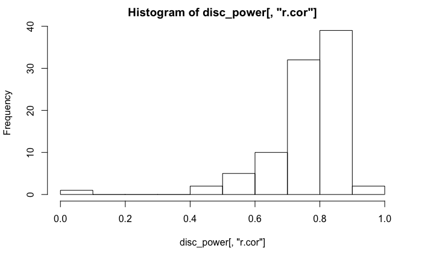

```r
disc_power <- data.frame()
for(i in constructs) {
  disc_power <- rbind(disc_power, alpha(df[,grep(i, names(df))])$item.stats["r.cor"])
}
hist(disc_power[,"r.cor"])
```

According to Borg and Groenen (2005), the lowest acceptable discriminatory power is .30. Any items that are below this value will be removed.

```r
row.names(disc_power)[disc_power < .3]
```

```
[1] "6_INTRINSIC_224"
```

```r
## this item will be removed
df <- df[,!(disc_power < .3)]
```

## Intercorrelation matrix + Homogeneity

Usually, the intercorrelation matrix of the scale is reported in the paper. In this particular case, the intercorrelation matrix for 93 items (or 90) is way too large to include. However, we can still investigate these correlations on a construct level.

Additionally, Homogeneity can be useful as a measure of the mean inter-item correlation of an item (Briggs and Cheek, 1986).  
We decided here to remove any items with an average inter-item correlation (Homogeneity) of less than .5.

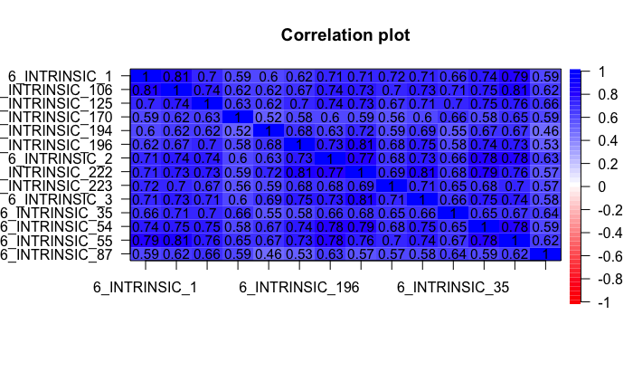

```r
df <- df[,!(names(df) %in% remove)]
```

# Exploratory factor analysis

## What is exploratory factor analysis?

The two main goals of factor analysis is 1) to reduce complexity in a data set with the identification of dimensions to which the variables correspond to (dimension reduction) that can be used for further analysis and 2) to test the construct validity of a questionnaire or test. There are two classes of methods: exploratory factor analysis and confirmatory factor analysis. In situations where there is a clear apriori hypothesis or theory of how certain variables (items) correspond to factors and one would like to test these hypotheses, confirmatory factor analysis is suitable. However, in cases where there is no clear understanding about the underlying structure of a questionnaire, exploratory factor analysis might be more appropriate in the first stages of developing a questionnaire.

The exploratory factor analysis can not test any hypotheses, and thus is usually applied at a first stage of the questionnaire development and when no clear relationships are theoretically expected or the number of items is unusally large.

## Steps in a exploratory factor analysis

First, a researcher has to decide which factor extraction method will be used. Then, a factor retention method should be selected and third, a method for factor rotation should be selected.

## How does exploratory factor analysis work?

For a set of observed response variables, the goal is to find a set of latent factors, *fewer* in number than the observed variables. These factors should explain the intercorrelations of the observed variables in the sense that when the factors are partialed out from the observed variables, there should no longer remain any correlations between these. The term exploratory means that it is unknown how many factors are needed and one does one know the factorial nature of the observed variables.

## When is factor analysis appropriate?

There are various recommendations about the appropriate number of participants in a sample to conduct factor analysis. In general, the more the better, but also the participant-to-variable ratio should be at least 5:1 or a sample size of at least 200 people seems appropriate.

## Bartlett’s test

This test examines whether the correlation matrix is significanlty different from an identity matrix (Hauptdiagonalelemente 1, Ausserdiagonalelemente 0). If the null hypothesis can not be rejected, the process of Factor Analysis has to stop right here. This would indicate that the correlations between the variables is just accidential.

```r
library(psych)
rmat <- cor(df, use = "complete.obs")
cortest.bartlett(rmat, nrow(df)) # there are 458 complete obs
```

```
$chisq
[1] 38778.11

$p.value
[1] 0

$df
[1] 3160
```

The result is highly significant - good!

## Kaiser-Meyer-Olkin measure (KMO)

Examines the Anti-Image correlation matrix (negative partial correlation matrix). The partial correlation between two variables is the correlation between these variables if influence of all the other variables has been subtracted out. If two variables have a common factor, the partial correlation betwwen these variables should be approximately zero. A factor analysis is only appropriate if these partial correlations have no substantial correlation.  
The KMO measure of factor adequacy is the sum of the bivariate correlations divided by the sum of the bivariate correlations and the sum of the partial correlations. This KMO measure is limited by 1. Values close to 1 indicate low partial correlations, which is a sign of common factors.

```r
KMO(rmat)
```

```
Kaiser-Meyer-Olkin factor adequacy
Call: KMO(r = rmat)
Overall MSA =  0.97
MSA for each item =
     1_AMOTIV_120       1_AMOTIV_13       1_AMOTIV_16      1_AMOTIV_189      1_AMOTIV_191      1_AMOTIV_192
             0.95              0.96              0.97              0.95              0.93              0.96
     1_AMOTIV_213      1_AMOTIV_214      1_AMOTIV_215      1_AMOTIV_216      1_AMOTIV_226      1_AMOTIV_228
             0.96              0.96              0.96              0.97              0.95              0.95
      1_AMOTIV_52       1_AMOTIV_83       1_AMOTIV_84       1_AMOTIV_85    2_EXTERNAL_119    2_EXTERNAL_162
             0.97              0.96              0.96              0.97              0.96              0.92
   2_EXTERNAL_164    2_EXTERNAL_165     2_EXTERNAL_32     2_EXTERNAL_66     2_EXTERNAL_67 3_INTROJECTED_115
             0.94              0.95              0.94              0.94              0.94              0.98
3_INTROJECTED_116 3_INTROJECTED_137 3_INTROJECTED_182 3_INTROJECTED_205 3_INTROJECTED_206 3_INTROJECTED_208
             0.96              0.96              0.97              0.96              0.96              0.97
3_INTROJECTED_218 3_INTROJECTED_219  3_INTROJECTED_25  3_INTROJECTED_26  3_INTROJECTED_28  3_INTROJECTED_61
             0.96              0.96              0.96              0.96              0.96              0.97
 3_INTROJECTED_97  4_IDENTIFIED_155  4_IDENTIFIED_201  4_IDENTIFIED_230  4_IDENTIFIED_233  4_IDENTIFIED_234
             0.97              0.97              0.98              0.98              0.98              0.98
 4_IDENTIFIED_248   4_IDENTIFIED_59    4_IDENTIFIED_6    4_IDENTIFIED_8  5_INTEGRATED_108  5_INTEGRATED_110
             0.98              0.98              0.97              0.98              0.98              0.98
 5_INTEGRATED_129  5_INTEGRATED_153  5_INTEGRATED_197  5_INTEGRATED_198  5_INTEGRATED_199  5_INTEGRATED_200
             0.98              0.97              0.98              0.98              0.98              0.99
 5_INTEGRATED_241  5_INTEGRATED_242  5_INTEGRATED_243  5_INTEGRATED_300  5_INTEGRATED_301  5_INTEGRATED_302
             0.97              0.98              0.98              0.97              0.97              0.97
 5_INTEGRATED_303  5_INTEGRATED_304  5_INTEGRATED_305   5_INTEGRATED_90   5_INTEGRATED_91   5_INTEGRATED_92
             0.98              0.97              0.98              0.98              0.98              0.97
    6_INTRINSIC_1   6_INTRINSIC_106   6_INTRINSIC_125   6_INTRINSIC_170   6_INTRINSIC_194   6_INTRINSIC_196
             0.96              0.96              0.98              0.98              0.97              0.96
    6_INTRINSIC_2   6_INTRINSIC_222   6_INTRINSIC_223     6_INTRINSIC_3    6_INTRINSIC_35    6_INTRINSIC_54
             0.98              0.96              0.97              0.97              0.98              0.98
   6_INTRINSIC_55    6_INTRINSIC_87
             0.97              0.98
```

All above .60 (Howard, 2016), so its quite good.

### Determine number of factors

There are several procedures to decided how many factors to retain. The classic (SPSS) approach is to retain factors with eigenvalues larger than 1. This basically means that the variance explained by this factor is higher than those explaned by any variable in the data. However, this criterion is very arbitrary, since factors can be by coincidence just below 1 (Kaiser criterion). One of the better approaches is the analysis of Scree Plots, in which an investigater subjectively decideds where the “knee” of the plot is, and keeps all the factors above this knee. A different but also very convincing approach is to use Parallel Analysis. The basic idea of Parallel Analysis is that the found number of factors is compared to a number of factors extracted from data with random correlations.

```
Parallel analysis suggests that the number of factors =  6  and the number of components =  4
```

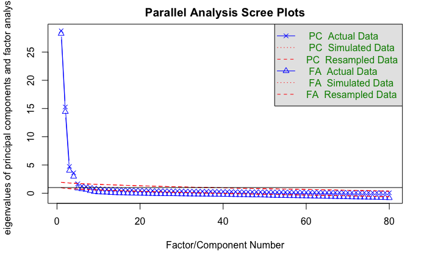

```r
fa.parallel(df, fm = "pa")
```

Parallel Analysis suggests 6 factors - great!

## Factor analysis

Test multivariate normality.

```r
library(MVN)
mardiaTest(df)
```

```
   Mardia's Multivariate Normality Test
---------------------------------------
   data : df

   g1p            : 2063.153
   chi.skew       : 162301.4
   p.value.skew   : 0

   g2p            : 7910.33
   z.kurtosis     : 128.0602
   p.value.kurt   : 0

   chi.small.skew : 163358.6
   p.value.small  : 0

   Result          : Data are not multivariate normal.
---------------------------------------
```

```r
hzTest(df)
```

```
  Henze-Zirkler's Multivariate Normality Test
---------------------------------------------
  data : df

  HZ      : 1.000002
  p-value : 0

  Result  : Data are not multivariate normal.
---------------------------------------------
```

```r
roystonTest(df)
```

```
  Royston's Multivariate Normality Test
---------------------------------------------
  data : df

  H       : 5584.593
  p-value : 0

  Result  : Data are not multivariate normal.
---------------------------------------------
```

Clearly data are NOT normal. Thus, we select principal axis factoring instead of maximum likelihood.

```r
fit <- fa(df, nfactors=6, n.iter=1, rotate = "oblimin", fm="pa")
fit
```

```
Factor Analysis using method =  pa
Call: fa(r = df, nfactors = 6, n.iter = 1, rotate = "oblimin", fm = "pa")
Standardized loadings (pattern matrix) based upon correlation matrix
                    PA1   PA2   PA3   PA4   PA5   PA6   h2   u2 com
1_AMOTIV_120       0.03  0.85  0.02 -0.04  0.10  0.05 0.73 0.27 1.0
1_AMOTIV_13        0.02  0.59 -0.14  0.17 -0.04 -0.16 0.53 0.47 1.4
1_AMOTIV_16       -0.06  0.85  0.03 -0.02  0.04  0.08 0.70 0.30 1.0
1_AMOTIV_189       0.02  0.88 -0.01  0.00  0.00 -0.01 0.78 0.22 1.0
1_AMOTIV_191      -0.07  0.62  0.04  0.15 -0.07 -0.12 0.45 0.55 1.3
1_AMOTIV_192      -0.03  0.78 -0.03 -0.10  0.16  0.03 0.69 0.31 1.1
1_AMOTIV_213      -0.01  0.88  0.02 -0.11  0.13  0.03 0.79 0.21 1.1
1_AMOTIV_214       0.07  0.82 -0.09 -0.03  0.09  0.08 0.74 0.26 1.1
1_AMOTIV_215       0.06  0.76 -0.08  0.12 -0.10 -0.07 0.64 0.36 1.1
1_AMOTIV_216       0.01  0.90  0.03 -0.02  0.00  0.02 0.78 0.22 1.0
1_AMOTIV_226       0.06  0.61 -0.02  0.08 -0.09 -0.12 0.40 0.60 1.2
1_AMOTIV_228      -0.03  0.74 -0.02  0.17 -0.15 -0.06 0.58 0.42 1.2
1_AMOTIV_52       -0.07  0.90  0.07  0.01 -0.02 -0.01 0.78 0.22 1.0
1_AMOTIV_83       -0.04  0.74 -0.11  0.07 -0.04 -0.07 0.68 0.32 1.1
1_AMOTIV_84       -0.01  0.92  0.00 -0.03  0.01  0.02 0.84 0.16 1.0
1_AMOTIV_85        0.00  0.76 -0.11  0.00 -0.01 -0.02 0.66 0.34 1.0
2_EXTERNAL_119     0.29  0.04 -0.03  0.20  0.34  0.04 0.45 0.55 2.7
2_EXTERNAL_162     0.07  0.07  0.00  0.03  0.62  0.09 0.48 0.52 1.1
2_EXTERNAL_164     0.04  0.04  0.08 -0.02  0.75  0.01 0.60 0.40 1.0
2_EXTERNAL_165     0.09  0.12 -0.07  0.32  0.49 -0.07 0.62 0.38 2.0
2_EXTERNAL_32     -0.04  0.06 -0.05  0.36  0.61 -0.05 0.74 0.26 1.7
2_EXTERNAL_66      0.07 -0.01 -0.03  0.10  0.79 -0.03 0.76 0.24 1.1
2_EXTERNAL_67      0.01  0.17 -0.02  0.07  0.67  0.03 0.61 0.39 1.2
3_INTROJECTED_115  0.41  0.03  0.19  0.39 -0.03  0.11 0.67 0.33 2.6
3_INTROJECTED_116  0.33  0.09 -0.03  0.49  0.01 -0.17 0.50 0.50 2.1
3_INTROJECTED_137  0.27  0.01  0.06  0.49  0.03  0.04 0.51 0.49 1.6
3_INTROJECTED_182  0.06  0.00  0.03  0.83 -0.05  0.05 0.72 0.28 1.0
3_INTROJECTED_205 -0.10 -0.02  0.02  0.80  0.13  0.07 0.69 0.31 1.1
3_INTROJECTED_206  0.08  0.03 -0.04  0.68  0.13 -0.04 0.65 0.35 1.1
3_INTROJECTED_208  0.01  0.04 -0.04  0.79  0.04  0.06 0.68 0.32 1.0
3_INTROJECTED_218 -0.05 -0.06 -0.04  0.67  0.32 -0.01 0.73 0.27 1.5
3_INTROJECTED_219  0.13  0.00 -0.01  0.49  0.29 -0.11 0.57 0.43 1.9
3_INTROJECTED_25   0.24  0.07  0.01  0.61  0.02 -0.08 0.60 0.40 1.4
3_INTROJECTED_26   0.01  0.02 -0.04  0.77  0.16 -0.06 0.75 0.25 1.1
3_INTROJECTED_28   0.08  0.11  0.33  0.45 -0.01  0.11 0.47 0.53 2.2
3_INTROJECTED_61  -0.06  0.02  0.04  0.81  0.05  0.07 0.70 0.30 1.0
```

[output cut: 67 more lines]

```
The root mean square of the residuals (RMSR) is  0.02
The df corrected root mean square of the residuals is  0.02

The harmonic number of observations is  472 with the empirical chi square  1550.76  with prob <  1
The total number of observations was  472  with Likelihood Chi Square =  5680.78  with prob <  1.1e-214

Tucker Lewis Index of factoring reliability =  0.901
RMSEA index =  0.052  and the 90 % confidence intervals are  0.047 NA
BIC =  -10912.28
Fit based upon off diagonal values = 1
Measures of factor score adequacy
                                                   PA1  PA2  PA3  PA4  PA5  PA6
Correlation of (regression) scores with factors   0.99 0.99 0.99 0.98 0.95 0.90
Multiple R square of scores with factors          0.98 0.97 0.97 0.95 0.91 0.82
Minimum correlation of possible factor scores     0.96 0.95 0.95 0.90 0.82 0.63
```

```r
fit$communality
```

```
     1_AMOTIV_120       1_AMOTIV_13       1_AMOTIV_16      1_AMOTIV_189      1_AMOTIV_191      1_AMOTIV_192
        0.7335349         0.5338837         0.6997468         0.7771541         0.4488890         0.6891961
     1_AMOTIV_213      1_AMOTIV_214      1_AMOTIV_215      1_AMOTIV_216      1_AMOTIV_226      1_AMOTIV_228
        0.7917429         0.7397271         0.6385453         0.7769740         0.3995464         0.5763627
      1_AMOTIV_52       1_AMOTIV_83       1_AMOTIV_84       1_AMOTIV_85    2_EXTERNAL_119    2_EXTERNAL_162
        0.7802385         0.6769363         0.8383225         0.6635777         0.4517513         0.4839029
   2_EXTERNAL_164    2_EXTERNAL_165     2_EXTERNAL_32     2_EXTERNAL_66     2_EXTERNAL_67 3_INTROJECTED_115
        0.6008933         0.6215483         0.7430281         0.7603336         0.6112520         0.6700374
3_INTROJECTED_116 3_INTROJECTED_137 3_INTROJECTED_182 3_INTROJECTED_205 3_INTROJECTED_206 3_INTROJECTED_208
        0.4978186         0.5147076         0.7188843         0.6917667         0.6452003         0.6808358
3_INTROJECTED_218 3_INTROJECTED_219  3_INTROJECTED_25  3_INTROJECTED_26  3_INTROJECTED_28  3_INTROJECTED_61
        0.7257989         0.5672773         0.5999322         0.7497793         0.4662325         0.7008254
 3_INTROJECTED_97  4_IDENTIFIED_155  4_IDENTIFIED_201  4_IDENTIFIED_230  4_IDENTIFIED_233  4_IDENTIFIED_234
        0.5780942         0.5876300         0.6479528         0.6616941         0.6894635         0.6546422
 4_IDENTIFIED_248   4_IDENTIFIED_59    4_IDENTIFIED_6    4_IDENTIFIED_8  5_INTEGRATED_108  5_INTEGRATED_110
        0.5636215         0.5949169         0.5500381         0.7614749         0.7786574         0.7942069
 5_INTEGRATED_129  5_INTEGRATED_153  5_INTEGRATED_197  5_INTEGRATED_198  5_INTEGRATED_199  5_INTEGRATED_200
        0.7412435         0.6431770         0.5730051         0.6646381         0.6693875         0.6493925
 5_INTEGRATED_241  5_INTEGRATED_242  5_INTEGRATED_243  5_INTEGRATED_300  5_INTEGRATED_301  5_INTEGRATED_302
        0.6720800         0.6741591         0.7753212         0.7591975         0.6776460         0.6941850
 5_INTEGRATED_303  5_INTEGRATED_304  5_INTEGRATED_305   5_INTEGRATED_90   5_INTEGRATED_91   5_INTEGRATED_92
        0.7545370         0.6451852         0.7356099         0.6542102         0.6627837         0.8157563
    6_INTRINSIC_1   6_INTRINSIC_106   6_INTRINSIC_125   6_INTRINSIC_170   6_INTRINSIC_194   6_INTRINSIC_196
        0.7109285         0.7671518         0.7423106         0.5758661         0.5755697         0.6886517
    6_INTRINSIC_2   6_INTRINSIC_222   6_INTRINSIC_223     6_INTRINSIC_3    6_INTRINSIC_35    6_INTRINSIC_54
        0.7446771         0.7777390         0.6470361         0.7467193         0.6766237         0.7824423
   6_INTRINSIC_55    6_INTRINSIC_87
        0.7946755         0.5604059
```

```r
print(fit, digits=2, sort=T)
```

```
Factor Analysis using method =  pa
Call: fa(r = df, nfactors = 6, n.iter = 1, rotate = "oblimin", fm = "pa")
Standardized loadings (pattern matrix) based upon correlation matrix
                  item   PA1   PA2   PA3   PA4   PA5   PA6   h2   u2 com
5_INTEGRATED_110    48  0.93  0.02 -0.03 -0.01  0.05 -0.09 0.79 0.21 1.0
5_INTEGRATED_108    47  0.88  0.01  0.07  0.01  0.01 -0.12 0.78 0.22 1.1
5_INTEGRATED_129    49  0.88 -0.04 -0.03 -0.05  0.09 -0.03 0.74 0.26 1.0
5_INTEGRATED_301    59  0.88  0.05 -0.02 -0.04  0.03 -0.08 0.68 0.32 1.0
5_INTEGRATED_300    58  0.85 -0.02  0.00  0.02  0.02  0.00 0.76 0.24 1.0
5_INTEGRATED_243    57  0.84 -0.07 -0.09  0.01  0.03  0.12 0.78 0.22 1.1
5_INTEGRATED_92     66  0.84 -0.05  0.00  0.11 -0.01  0.01 0.82 0.18 1.0
5_INTEGRATED_242    56  0.81  0.01  0.08 -0.06  0.06 -0.05 0.67 0.33 1.1
5_INTEGRATED_302    60  0.78 -0.02 -0.10  0.01  0.01  0.18 0.69 0.31 1.1
5_INTEGRATED_241    55  0.77  0.04  0.00  0.04  0.00  0.06 0.67 0.33 1.0
5_INTEGRATED_304    62  0.77 -0.05 -0.07 -0.01  0.00  0.14 0.65 0.35 1.1
5_INTEGRATED_303    61  0.76 -0.03 -0.11  0.05 -0.02  0.25 0.75 0.25 1.3
5_INTEGRATED_200    54  0.74  0.00  0.05 -0.02  0.05  0.06 0.65 0.35 1.0
5_INTEGRATED_199    53  0.73 -0.02  0.16  0.01  0.02 -0.03 0.67 0.33 1.1
5_INTEGRATED_90     64  0.73  0.01  0.15  0.04  0.04 -0.10 0.65 0.35 1.1
5_INTEGRATED_198    52  0.73  0.03  0.19  0.02  0.04 -0.09 0.66 0.34 1.2
5_INTEGRATED_305    63  0.72 -0.01  0.00  0.14 -0.03  0.13 0.74 0.26 1.2
5_INTEGRATED_153    50  0.66  0.05  0.20  0.12 -0.01 -0.08 0.64 0.36 1.3
4_IDENTIFIED_233    41  0.52  0.00  0.06  0.14  0.05  0.31 0.69 0.31 1.9
5_INTEGRATED_197    51  0.51 -0.06  0.25  0.01 -0.01  0.14 0.57 0.43 1.7
4_IDENTIFIED_59     44  0.49 -0.15  0.10  0.19  0.04  0.12 0.59 0.41 1.8
5_INTEGRATED_91     65  0.48  0.01  0.23  0.23 -0.09  0.17 0.66 0.34 2.4
4_IDENTIFIED_230    40  0.46 -0.06  0.05  0.09  0.02  0.40 0.66 0.34 2.1
4_IDENTIFIED_248    43  0.46  0.07  0.20  0.00  0.01  0.30 0.56 0.44 2.2
4_IDENTIFIED_8      46  0.44 -0.10  0.24  0.12  0.01  0.31 0.76 0.24 2.8
3_INTROJECTED_115   24  0.41  0.03  0.19  0.39 -0.03  0.11 0.67 0.33 2.6
4_IDENTIFIED_6      45  0.34 -0.18  0.31  0.04  0.03  0.16 0.55 0.45 3.1
1_AMOTIV_84         15 -0.01  0.92  0.00 -0.03  0.01  0.02 0.84 0.16 1.0
1_AMOTIV_216        10  0.01  0.90  0.03 -0.02  0.00  0.02 0.78 0.22 1.0
1_AMOTIV_52         13 -0.07  0.90  0.07  0.01 -0.02 -0.01 0.78 0.22 1.0
1_AMOTIV_189         4  0.02  0.88 -0.01  0.00  0.00 -0.01 0.78 0.22 1.0
1_AMOTIV_213         7 -0.01  0.88  0.02 -0.11  0.13  0.03 0.79 0.21 1.1
1_AMOTIV_120         1  0.03  0.85  0.02 -0.04  0.10  0.05 0.73 0.27 1.0
1_AMOTIV_16          3 -0.06  0.85  0.03 -0.02  0.04  0.08 0.70 0.30 1.0
1_AMOTIV_214         8  0.07  0.82 -0.09 -0.03  0.09  0.08 0.74 0.26 1.1
1_AMOTIV_192         6 -0.03  0.78 -0.03 -0.10  0.16  0.03 0.69 0.31 1.1
```

[output cut: 67 more lines]

```
The root mean square of the residuals (RMSR) is  0.02
The df corrected root mean square of the residuals is  0.02

The harmonic number of observations is  472 with the empirical chi square  1550.76  with prob <  1
The total number of observations was  472  with Likelihood Chi Square =  5680.78  with prob <  1.1e-214

Tucker Lewis Index of factoring reliability =  0.901
RMSEA index =  0.052  and the 90 % confidence intervals are  0.047 NA
BIC =  -10912.28
Fit based upon off diagonal values = 1
Measures of factor score adequacy
                                                   PA1  PA2  PA3  PA4  PA5  PA6
Correlation of (regression) scores with factors   0.99 0.99 0.99 0.98 0.95 0.90
Multiple R square of scores with factors          0.98 0.97 0.97 0.95 0.91 0.82
Minimum correlation of possible factor scores     0.96 0.95 0.95 0.90 0.82 0.63
```

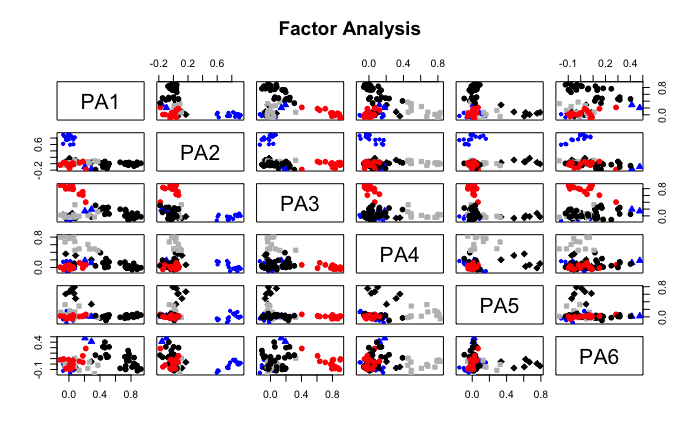

```r
fa.plot(fit, cut = .3, show.points=TRUE)
```

```r
# plot
#f3.p <- fit$loadings
#plot.new()
#mod.f3p <- structure.diagram(f3.p,cut=.3, cex=.4, e.size = 0.4)
```

## Investiage alternative with 5 factors

```r
fit.five
```

```
Factor Analysis using method =  pa
Call: fa(r = df, nfactors = 5, n.iter = 1, rotate = "oblimin", fm = "pa")
Standardized loadings (pattern matrix) based upon correlation matrix
                    PA1   PA2   PA3   PA4   PA5   h2   u2 com
1_AMOTIV_120       0.06  0.84  0.01 -0.05  0.11 0.73 0.27 1.1
1_AMOTIV_13       -0.08  0.61 -0.13  0.20 -0.06 0.53 0.47 1.4
1_AMOTIV_16       -0.01  0.83  0.03 -0.05  0.06 0.69 0.31 1.0
1_AMOTIV_189       0.02  0.88 -0.01  0.00  0.00 0.78 0.22 1.0
1_AMOTIV_191      -0.15  0.63  0.04  0.18 -0.08 0.45 0.55 1.3
1_AMOTIV_192      -0.02  0.77 -0.03 -0.10  0.16 0.69 0.31 1.1
1_AMOTIV_213       0.01  0.87  0.02 -0.11  0.14 0.79 0.21 1.1
1_AMOTIV_214       0.12  0.81 -0.09 -0.05  0.10 0.73 0.27 1.1
1_AMOTIV_215       0.01  0.76 -0.08  0.13 -0.11 0.64 0.36 1.1
1_AMOTIV_216       0.02  0.90  0.03 -0.03  0.01 0.77 0.23 1.0
1_AMOTIV_226      -0.01  0.62 -0.01  0.10 -0.10 0.40 0.60 1.1
1_AMOTIV_228      -0.07  0.74 -0.01  0.17 -0.15 0.58 0.42 1.2
1_AMOTIV_52       -0.08  0.90  0.07  0.00 -0.01 0.78 0.22 1.0
1_AMOTIV_83       -0.08  0.75 -0.11  0.09 -0.04 0.68 0.32 1.1
1_AMOTIV_84        0.00  0.92  0.00 -0.04  0.02 0.83 0.17 1.0
1_AMOTIV_85       -0.02  0.76 -0.11  0.00 -0.01 0.66 0.34 1.0
2_EXTERNAL_119     0.32  0.04 -0.04  0.22  0.32 0.45 0.55 2.8
2_EXTERNAL_162     0.11  0.07 -0.01  0.04  0.61 0.48 0.52 1.1
2_EXTERNAL_164     0.04  0.06  0.07  0.03  0.72 0.60 0.40 1.0
2_EXTERNAL_165     0.04  0.14 -0.07  0.37  0.45 0.61 0.39 2.2
2_EXTERNAL_32     -0.08  0.08 -0.05  0.41  0.57 0.74 0.26 1.9
2_EXTERNAL_66      0.04  0.02 -0.03  0.17  0.74 0.75 0.25 1.1
2_EXTERNAL_67      0.02  0.18 -0.02  0.10  0.65 0.61 0.39 1.2
3_INTROJECTED_115  0.49  0.02  0.18  0.36 -0.02 0.67 0.33 2.1
3_INTROJECTED_116  0.23  0.12 -0.03  0.54 -0.02 0.47 0.53 1.5
3_INTROJECTED_137  0.30  0.00  0.06  0.48  0.02 0.51 0.49 1.7
3_INTROJECTED_182  0.11 -0.02  0.03  0.80 -0.05 0.71 0.29 1.1
3_INTROJECTED_205 -0.04 -0.05  0.03  0.78  0.12 0.68 0.32 1.1
3_INTROJECTED_206  0.07  0.03 -0.03  0.70  0.11 0.65 0.35 1.1
3_INTROJECTED_208  0.06  0.02 -0.04  0.77  0.04 0.67 0.33 1.0
3_INTROJECTED_218 -0.05 -0.06 -0.03  0.69  0.30 0.73 0.27 1.4
3_INTROJECTED_219  0.07  0.03  0.00  0.54  0.25 0.56 0.44 1.4
3_INTROJECTED_25   0.21  0.08  0.02  0.63 -0.01 0.60 0.40 1.3
3_INTROJECTED_26  -0.01  0.02 -0.04  0.79  0.13 0.75 0.25 1.1
3_INTROJECTED_28   0.16  0.09  0.32  0.42  0.00 0.46 0.54 2.3
3_INTROJECTED_61   0.01  0.00  0.05  0.79  0.06 0.69 0.31 1.0
```

[output cut: 66 more lines]

```
The root mean square of the residuals (RMSR) is  0.03
The df corrected root mean square of the residuals is  0.03

The harmonic number of observations is  472 with the empirical chi square  1932.28  with prob <  1
The total number of observations was  472  with Likelihood Chi Square =  6292.75  with prob <  3.4e-274

Tucker Lewis Index of factoring reliability =  0.886
RMSEA index =  0.055  and the 90 % confidence intervals are  0.05 NA
BIC =  -10762.08
Fit based upon off diagonal values = 1
Measures of factor score adequacy
                                                   PA1  PA2  PA3  PA4  PA5
Correlation of (regression) scores with factors   0.99 0.99 0.99 0.98 0.95
Multiple R square of scores with factors          0.98 0.97 0.97 0.95 0.90
Minimum correlation of possible factor scores     0.96 0.95 0.95 0.90 0.79
```

As a next step, a researcher needs to carfully decided on which items to remove and which to retain.

# Confirmatory factor analysis

Confirmatory Factor Analysis (CFA) describes the measurement model part in methods for Structural Equation Modelling (SEM). The goal of CFA is data reduction; however, in contrast to EFA, the reduction is theory-guided. Researchers test hypotheses regarding the number of underlying factors of the variables and the relationships between these factors. These hypotheses are drawn from theory and need to be known to conduct the analysis. In general, CFA tests whether sufficient conformance between the empirical data and the theoretical model can be found or whether the model needs to be respecified. CFA allows to test specific model or multiple possible models and compare them with a single data set.

More details on CFA can be found here (German only): [Structural Equation Models on R-Toolbox](https://mmi.psycho.unibas.ch/r-toolbox/sem.html)

## CFA steps

1. Specify model
2. Decide on the estimation method
3. Evaluate the model

### Specify model

Decide how many factors underly the data, whether these factors have some relationship between them, and which indicators (manifest variables) load on which factor. Ideally, draft this on a paper and then create a digital visual representation of the model.

It is crucial that the model is *identifiable*. This means that the number of empirical variances and covariances of the manifest indicator variables need to be larger than the number of estimated parameters. In essence, the model requires a positive number of degrees of freedom.

### Estimation method

There are several estimation methods which provide different advantages and disadvantages. Historically, maximum-likelihood is the most frequently applied since. However, this method requires *interval scaled variables* and *multivariate normal distribution*. Especially the later is almost never given, and with Likert-type scales, interval scale properties are also often disputed.

A more detailed discussion of different estimation methods can be found [here](http://lavaan.ugent.be/tutorial/est.html). In practice, it often makes sense to use a robust estimation method.

### Model evaluation

Several alternative model fit indicators exist. The most prominent (and most strict) measure is the $\chi^{2}$-Value. It should be as low as possible, and the related p-value should be *not* significant, $p>.05$ (Hooper, Coughlan, & Mullen, 2008). Alternatively, Root Mean Square Error of Approximation (RMSEA) as a measure of approximate fit can be used. The RMSEA should be below $.05$, and its associated test (PCLOSE) should be not significant. The Standardized Root Mean Square Residual (SRMR) is an alternative measure that is dependent on sample size and should ideally also be below $.05$. Other descriptive measures (see Table below) include GFI and CFI measures which compare the model with a more or less sensible null model (e.g., all manifest variables uncorrelated).

Fit indices for CFA model evaluation.

[output not shown]

## CFA Example

The EFA example includes two models, the six and five-factor model for the User Motivation Inventory. While the results of these two EFAs are interesting to help decide which items to remove or retain, one may be interested in testing whether 6 or 5 factors better describe the data. This can be specified and tested with CFA.

For this example, we use only the 18 items included in the final version of the UMI.

```r
library(lavaan) # R package for SEM
```

### Test multivariate normality

```r
mardiaTest(df_cfa)
```

```
   Mardia's Multivariate Normality Test
---------------------------------------
   data : df_cfa

   g1p            : 65.60019
   chi.skew       : 5160.548
   p.value.skew   : 0

   g2p            : 494.7636
   z.kurtosis     : 54.55661
   p.value.kurt   : 0

   chi.small.skew : 5196.818
   p.value.small  : 0

   Result          : Data are not multivariate normal.
---------------------------------------
```

Since data are not normal we use a robust estimator for the CFA.

### Run CFA

```r
summary(fit_6f, fit.measures = TRUE, standardized = TRUE)
```

```
lavaan (0.5-23.1097) converged normally after  62 iterations

  Number of observations                           472

  Estimator                                         ML      Robust
  Minimum Function Test Statistic              222.866     180.755
  Degrees of freedom                               120         120
  P-value (Chi-square)                           0.000       0.000
  Scaling correction factor                                  1.233
    for the Yuan-Bentler correction

Model test baseline model:

  Minimum Function Test Statistic             5773.957    4060.689
  Degrees of freedom                               153         153
  P-value                                        0.000       0.000

User model versus baseline model:

  Comparative Fit Index (CFI)                    0.982       0.984
  Tucker-Lewis Index (TLI)                       0.977       0.980

  Robust Comparative Fit Index (CFI)                         0.987
  Robust Tucker-Lewis Index (TLI)                            0.983

Loglikelihood and Information Criteria:

  Loglikelihood user model (H0)             -13162.049  -13162.049
  Scaling correction factor                                  1.571
    for the MLR correction
  Loglikelihood unrestricted model (H1)     -13050.616  -13050.616
  Scaling correction factor                                  1.357
    for the MLR correction

  Number of free parameters                         69          69
  Akaike (AIC)                               26462.099   26462.099
  Bayesian (BIC)                             26748.930   26748.930
  Sample-size adjusted Bayesian (BIC)        26529.936   26529.936

Root Mean Square Error of Approximation:
```

[output cut: 105 more lines]

```
   .ij1               0.603    0.115    5.267    0.000    0.603    0.263
   .ij2               0.495    0.090    5.524    0.000    0.495    0.264
   .ij3               0.593    0.102    5.827    0.000    0.593    0.374
   .ex1               1.306    0.154    8.494    0.000    1.306    0.452
   .ex2               0.426    0.115    3.692    0.000    0.426    0.190
   .ex3               1.004    0.152    6.603    0.000    1.004    0.476
   .am1               0.630    0.116    5.445    0.000    0.630    0.194
   .am2               0.747    0.145    5.166    0.000    0.747    0.237
   .am3               0.473    0.122    3.880    0.000    0.473    0.163
    IMO               1.324    0.109   12.112    0.000    1.000    1.000
    INT               2.344    0.184   12.733    0.000    1.000    1.000
    IDE               1.604    0.165    9.707    0.000    1.000    1.000
    INJ               1.692    0.200    8.452    0.000    1.000    1.000
    EXT               1.583    0.186    8.531    0.000    1.000    1.000
    AMO               2.623    0.203   12.917    0.000    1.000    1.000
```

Although the $\chi^{2}$-test is significant, the RMSEA, SRMR, and the baseline comparisons suggest an acceptable fit. If we wanted to identify parts which could be improved we can use the `modificationIndices()` and `resid()`functions.

```r
head(modificationIndices(fit_6f, sort. = T), 5)
```

```
    lhs op rhs     mi mi.scaled    epc sepc.lv sepc.all sepc.nox
171 AMO =~ ex3 30.950    25.102  0.197   0.318    0.219    0.219
151 EXT =~ ij1 20.481    16.611 -0.265  -0.333   -0.220   -0.220
310 ex1 ~~ ex2 16.768    13.600  0.427   0.427    0.168    0.168
103 INT =~ ij1 14.037    11.385  0.154   0.236    0.155    0.155
104 INT =~ ij2 12.207     9.901 -0.130  -0.199   -0.145   -0.145
```

```r
summary(resid(fit_6f, "standardized")) # investigate residuals
```

```
     Length Class                   Mode
type   1    -none-                  character
cov  324    lavaan.matrix.symmetric numeric
mean  18    lavaan.vector           numeric
```

More information on model specification and improvement can be found [here (German only)](https://mmi.psycho.unibas.ch/r-toolbox/sem.html).

### Model comparison

Let’s compare the six-factor model to the five-factor model (one factor for all identified and integrated items).

```r
aov
```

```
Scaled Chi Square Difference Test (method = "satorra.bentler.2001")

        Df   AIC   BIC  Chisq Chisq diff Df diff Pr(>Chisq)
fit_6f 120 26462 26749 222.87
fit_5f 125 26648 26914 419.18     156.25       5  < 2.2e-16 ***
---
Signif. codes:  0 ‘***’ 0.001 ‘**’ 0.01 ‘*’ 0.05 ‘.’ 0.1 ‘ ’ 1
```

> If the $\chi^{2}_{diff}$-value is significant, the “larger” model with more freely estimated parameters fits the data better than the “smaller” model in which the parameters in question are fixed. So it “pays off” to estimate the additional parameters and to prefer the “larger” model.

That’s what we observe here.

> In case the $\chi^{2}_{diff}$-value is insignificant, both models fit equally well statistically, so the parameters in question can be eliminated from the model (fixed to zero) and the “smaller” model can be accepted just as well.

For more details visit these pages [here](https://www.psychologie.uzh.ch/dam/jcr:ffffffff-b371-2797-0000-00000fda8f29/chisquare_diff_en.pdf) and the Script on the [R-Toolbox (German only)](https://mmi.psycho.unibas.ch/r-toolbox/sem.html).